# Ebola Outbreak Analysis - Sierra Leone 2014

AI Data Reporter

2025-08-28

## Executive Summary

This report analyzes the Ebola outbreak data from Sierra Leone in 2014, providing key insights into the timing, demographics, and geographic distribution of cases.

## Data Overview

The dataset contains **200** total cases, with **200** cases having onset dates, **196** cases with age information, and **200** cases with sex information.

## Key Findings

### 1. First Case Reported

The first Ebola case was reported on **May 18, 2014** in the Kailahun district.

### 2. Age Group with Most Cases (End of June 2014)

As of the end of June 2014, the **30-39** age group had the most cases with **43** reported cases.

### 3. Median Age of Affected Individuals

The median age of those affected was **35** years, with ages ranging from **1.8** to **80** years.

### 4. Gender Distribution

There were **114** cases in women (57%) and **86** cases in men (43%). **Women** had more cases, with a difference of **28** cases.

### 5. District with Most Reported Cases

The district with the most reported cases was **Kailahun** with **155** cases.

## Visualizations

### Timeline of Cases

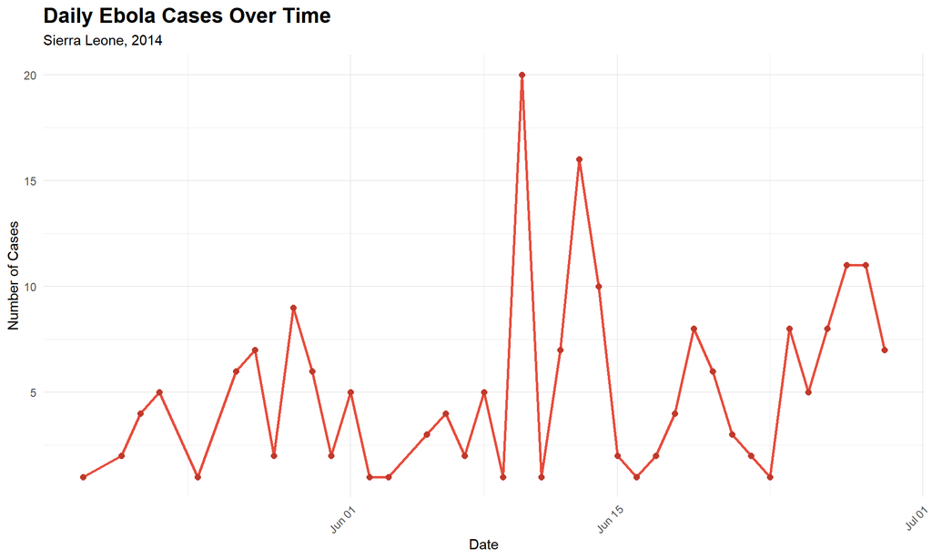

### Age Distribution by Gender

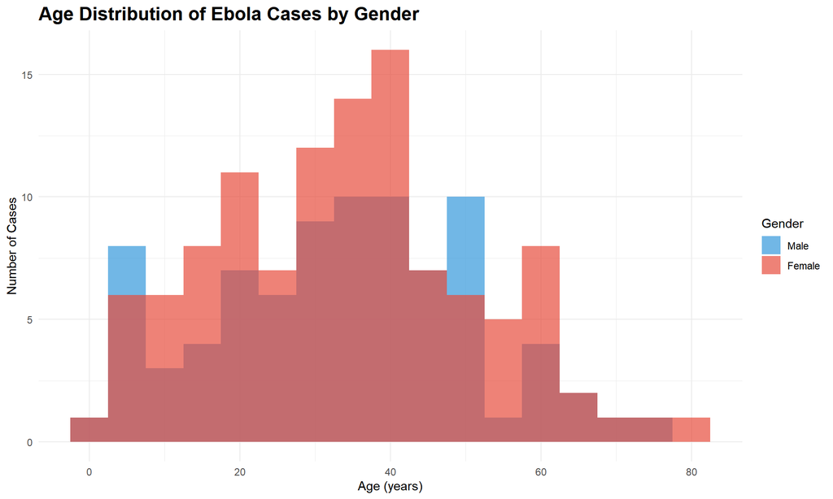

### District Case Distribution

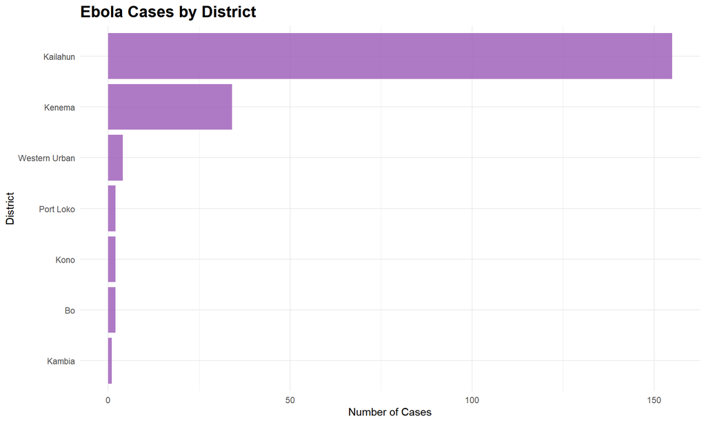

## Summary Tables

### Age Group Distribution (End of June 2014)

```
## **Age Group Distribution (End of June 2014):**
##
## - ** 30-39 :**  43  cases
## - ** 40-49 :**  38  cases
## - ** 20-29 :**  37  cases
## - ** 10-19 :**  29  cases
## - ** 0-9 :**  21  cases
## - ** 50-59 :**  16  cases
## - ** 60-69 :**  9  cases
## - ** 70-79 :**  3  cases
```

### District Case Summary

```
## **District Case Summary:**
##
## - ** Kailahun :**  155  cases
## - ** Kenema :**  34  cases
## - ** Western Urban :**  4  cases
## - ** Bo :**  2  cases
## - ** Kono :**  2  cases
## - ** Port Loko :**  2  cases
## - ** Kambia :**  1  cases
```

## Conclusion

This analysis reveals that the Ebola outbreak in Sierra Leone in 2014 affected individuals across all age groups, with the 30-39 age group being most impacted. The outbreak showed a slight gender disparity, with women being more affected. Geographically, Kailahun was the hardest-hit district, highlighting the need for targeted intervention strategies.

The data provides valuable insights for understanding the demographic patterns of the outbreak and can inform future public health responses to similar epidemics.